# PracticalMachineLearning

## Goal of the Project

The goal of this project is to predict the manner in which the classification was performed. This is the “classe” variable in the training set (*see problem description below*). In this report we will address the variables selection process and how these variables were used to predict the results for the test data provided. This report also describes the model building, cross validation, and the expected out of sample error. The reasoning made for the choices are also explained. Finally we also use the prediction model to predict 20 different test cases.

## Problem Description

Human Activity Research (HAR) is considered as a potential technology for health systems. For example, the HAR activity can be used to provide information about patients’ routines to support the development of e-health systems.

The data for the project has been collected based on HAR wearable devices (accelerometers) mounted on the eaist, keft thigh, right arm, and right ankle. The training data consists of 19622 samples, with 160 variables, including the classification variable “classe”. The variables included has the actual measurements from the device (e.g. roll belt, pitch belt etc.) as well as user name, timestam etc.

The original team involved in the reserach have performed classification of the HAR data successfully with very high accuracy. The problem is to trace the path the team followed in performing the classification and present the details.

## Model Building

### Data Exploration

When we look at the summary of the data we observe that there are many observations with NA (incomplete). The statistics collected shows:

```r
library(caret)
pmldata.df <- read.csv("pml-training.csv")
dim(pmldata.df)
```

```
## [1] 19622   160
```

```r
sum(complete.cases(pmldata.df))
```

```
## [1] 406
```

We have 159 predictor variables and 19622 rows, but the complete cases are only 406!

### Variable Selection

There are large number of variable, using all of these will not be effective and it may result in over fitting. So we need to apply some variable selection to reduce the number of variables used for prediction. After a review Of NAs we discard several columns and keep the following:

‘include.cols <- c(“roll_belt”, “pitch_belt”, “yaw_belt”, “total_accel_belt”, “gyros_belt_x”, “gyros_belt_y”, “gyros_belt_z”, “accel_belt_x”, “accel_belt_y”, “accel_belt_z”, “magnet_belt_x”, “magnet_belt_y”, “magnet_belt_z”, “roll_arm”, “pitch_arm”, “yaw_arm”, “total_accel_arm”, “gyros_arm_x”, “gyros_arm_y”, “gyros_arm_z”, “accel_arm_x”, “accel_arm_y”, “accel_arm_z”, “magnet_arm_x”, “magnet_arm_y”, “magnet_arm_z”, “roll_dumbbell”, “pitch_dumbbell”, “yaw_dumbbell”, “total_accel_dumbbell”, “gyros_dumbbell_x”, “gyros_dumbbell_y”, “gyros_dumbbell_z”, “accel_dumbbell_x”, “accel_dumbbell_y”, “accel_dumbbell_z”, “magnet_dumbbell_x”, “magnet_dumbbell_y”, “magnet_dumbbell_z”, “roll_forearm”, “pitch_forearm”, “yaw_forearm”, “total_accel_forearm”, “gyros_forearm_x”, “gyros_forearm_y”, “gyros_forearm_z”, “accel_forearm_x”, “accel_forearm_y”, “accel_forearm_z”, “magnet_forearm_x”, “magnet_forearm_y”, “magnet_forearm_z”)’

We are still left with 52 predictor (and 53 variables when we include the ‘classe’). It is clear that selecting an algorithm that can handle variable selection (or feature selection) will be advantageous. There are several such algorithms such as “C5”, “gbm”, “rf”, “part”, “rpart”, to mention a few. Many of these algorithms also tell us about the predictors used in the final model. We also can tune the behavior of these algorithms based on our data. We decoded to use this approach for variable selection than the one where the process has to be external and independent. We elected random forest among these as they are, Liaw and Wiener (2002):

1. Computationally efficient
2. Capable of operating over large data sets
3. Based on widely known Ensemble techniques of boosting and bagging, already proven efficient

### Random Forests

**Random forests** are “an *ensemble* learning method for classification (and regression) that operate by constructing a multitude of decision trees at training time and outputting the class that is the mode of the classes output by individual trees”, as described in [Wikepdia](http://en.wikipedia.org/wiki/Random_forest)“.

Random forests use a modified tree learning algorithm that selects, at each candidate split in the learning process, a random subset of the features, _the reason is that if one or a few features are very strong predictors for the response variable, these features will be selected in many of the B trees, causing them to become correlated. For a dataset with p features, $\sqrt(p)$, features are used in each split.

Random forests can also be used to rank the importance of variables in a regression or classification problem once we fit a fit a random forest to the data, see Breiman (2001)

We use the **randomForest** package, which optionally produces two additional pieces of information: a measure of the importance of the predictor variables, and a measure of the internal structure of the data (the proximity of different data points to one another).

## Analysis and Results

### Analysis

The analysis of the results and final prediction obtained from the investigation is presented in this section.

```r
## We remove some of the columns from the original data and retain the columns listed above
include.cols.cl <- c(include.cols, "classe")
training.use <- pmldata.df[,include.cols.cl]
set.seed(105)
modFit <- randomForest(classe ~ ., data = training.use, ntree = 2048)
```

We see the confusion matrix generated from this as:

```r
modFit$confusion
```

[output not shown]

We also show the variable importance graph that we can draw for the above model fit:

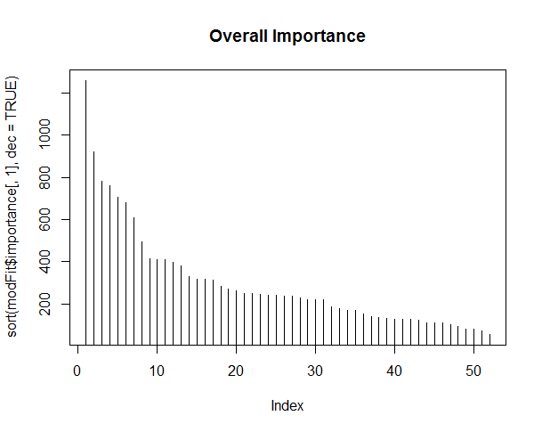

The vlaues of variables (Gini values) are as shown below (*we have chopped the middle portion and show only top 5 and bottom 5 values*):

```r
import <- varImp(modFit)
import$Variable <- row.names(import)
import[order(import$Overall, decreasing = T), ]
```

| Variable | Overall |
| --- | --- |
| roll_belt | 1260.34591 |
| yaw_belt | 922.76636 |
| pitch_forearm | 781.97362 |
| magnet_dumbbell_z | 759.95187 |
| pitch_belt | 707.05728 |
| … | … |
| gyros_belt_x | 94.55351 |
| gyros_forearm_z | 82.31437 |
| gyros_dumbbell_z | 82.26188 |
| gyros_forearm_x | 72.76551 |
| gyros_arm_z | 55.31264 |

Based on these observations, we could have further reduced the number of variables, for example, based on a cut off of, say 100, the last 5 variables could be eliminated without impacting the error rate.*We however chose to retain these variables*.

#### Number of Trees

We see that in the execution of the random forest algorithm we have specified the trees to be 2048. There has been research specifically to understand how this parameter could be determined and the impact, if any on the results, see Oshiro, Perez, and Baranauskas (2012)

| No. of Trees | User Time (millisec) |
| --- | --- |
| 128 | 18.38 |
| 256 | 36.39 |
| 512 | 74.51 |
| 1024 | 149.47 |
| 2048 | 306.67 |

### Prediction Results

The predicted results for the test cases are as follows:

| 1 | 2 | 3 | 4 | 5 | 6 | 7 | 8 | 9 | 10 | 11 | 12 | 13 | 14 | 15 | 16 | 17 | 18 | 19 | 20 |
| --- | --- | --- | --- | --- | --- | --- | --- | --- | --- | --- | --- | --- | --- | --- | --- | --- | --- | --- | --- |
| B | A | B | A | A | E | D | B | A | A | B | C | B | A | E | E | A | B | B | B |

## References

```
## [1] L. Breiman. "Random Forests". In: _Mach. Learn._ 45.1 (Oct.
## 2001), pp. 5-32.
##
## [2] A. Liaw and M. Wiener. "Classification and Regression by
## randomForest". In: _R News_ 2.3 (Dec. 2002), pp. 18-22. <URL:
## http://CRAN.R-project.org/doc/Rnews/>.
##
## [3] T. Oshiro, P. Perez and J. Baranauskas. "How Many Trees in a
## Random Forest?" In: _Machine Learning and Data Mining in Pattern
## Recognition_. Ed. by P. Perner. Vol. 7376. Lecture Notes in
## Computer Science. Springer Berlin Heidelberg, 2012, pp. 154-168.
## ISBN: 978-3-642-31536-7.
```